# Code City Cycles Trend Analysis Report

Data-Driven Management Analysis for a Specialty Bike Retailer

EV Polman, 659076798

2025-11-26

*Please do not share or distribute this document, nor the associated files, without explicit permission from EV.*

```r
accent <- "#D55E00"
theme_ev <- theme_minimal(base_size = 11) +
theme(
plot.title = element_text(face = "bold", size = 13),
plot.subtitle = element_text(size = 10),
axis.title = element_text(face = "bold"),
panel.grid.minor = element_blank()
)
```

# 1. Business Problem Definition

Code City Cycles, a specialty mountain bike retailer, wants to identify which product categories generate the highest in-store sales and which categories provide the strongest margins. By analyzing product-level sales, category performance, and monthly sales trends, the shop can adjust purchasing to better match demand, prioritize profitable categories, and reduce capital tied up in slow-moving stock. This analysis supports data-driven inventory planning based on real customer buying behaviour at Code City Cycles.

# 2. Data Source Assessment

The dataset was exported directly from Lightspeed Retail POS, the in-store transaction system used by Code City Cycles. Three CSV files were downloaded: product-level category sales, daily sales, and category performance summaries. Lightspeed collects this data for operational and financial management, including inventory optimization, margin analysis, and shop-floor purchasing decisions. The data represents real retail activity during 2024–2025. Limitations include occasional missing cost fields for specific service items, but overall completeness and reliability make this dataset well-suited for business decision-making.

## Data Source Attribution & URL

- Data source: Lightspeed Retail POS CSV exports
- Organization: Coal City Cycles
- Vendor URL: https://www.lightspeedhq.com/

## Data Access Method

**CSV Download Method: files exported from Lightspeed Retail POS and saved in the same folder as this R Markdown file.**

```r
category_sales <- read.csv("product_category_sales.csv")
daily_sales <- read.csv("daily_sales_summary.csv")
category_summary <- read.csv("category_performance_summary.csv")
```

**Basic structure checks**

```r
dim(category_sales)
```

```
## [1] 11993     8
```

```r
dim(daily_sales)
```

```
## [1] 577   8
```

```r
dim(category_summary)
```

```
## [1] 297   9
```

```r
str(category_sales)
```

```
## 'data.frame':    11993 obs. of  8 variables:
##  $ Product     : chr  "Park Tool, PW-5, Light duty pedal wrench" "Park Tool, ATD-1Adjustable torque driver, 4-6 Nm" "Park Tool, CNW-2, Chainring nut wrench" "Park Tool, TW-5.2, Torque Wrench" ...
##  $ Category    : chr  "Wrenches" "Wrenches" "Wrenches" "Wrenches" ...
##  $ Total.Sold  : int  46 37 16 12 7 6 4 4 2 1 ...
##  $ Unit.Cost   : num  9.67 52 3.58 98.24 14.99 ...
##  $ Total.Cost  : num  444.6 1924 57.2 1178.9 104.9 ...
##  $ Unit.Retail : num  20.48 97.39 8.85 196.76 23.99 ...
##  $ Total.Retail: num  942 3604 142 2361 168 ...
##  $ Margin      : num  52.8 46.6 59.6 50.1 37.5 ...
```

```r
str(daily_sales)
```

```
## 'data.frame':    577 obs. of  8 variables:
##  $ Date       : chr  "2024-01-02 00:00" "2024-01-03 00:00" "2024-01-04 00:00" "2024-01-05 00:00" ...
##  $ Sales.Count: int  16 11 22 22 21 13 12 7 7 10 ...
##  $ Subtotal   : chr  "$994.70" "$1,285.89" "$11,432.77" "$7,317.45" ...
##  $ Discounts  : chr  "$0.00" "$0.00" "$0.00" "$0.00" ...
##  $ Total      : chr  "$1,021.48" "$1,392.60" "$12,029.97" "$7,722.03" ...
##  $ Cost       : chr  "$372.10" "$695.81" "$12,958.28" "$6,814.52" ...
##  $ Profit     : chr  "$622.60" "$590.08" "$-1,525.51" "$502.93" ...
##  $ Margin     : chr  "34.69%" "45.89%" "-13.34%" "6.86%" ...
```

```r
str(category_summary)
```

```
## 'data.frame':    297 obs. of  9 variables:
##  $ Category             : chr  "Accessories - #8" "Bags/Baskets - #720" "Baskets - #880" "Bike Packing - #853" ...
##  $ Parent               : chr  "" "Accessories - #8" "Bags/Baskets - #720" "Bags/Baskets - #720" ...
##  $ Subtotal             : chr  "$129822.01" "$12967.37" "$19.99" "$4523.95" ...
##  $ Subtotal.w..Discounts: chr  "$129699.82" "$12940.17" "$19.99" "$4523.95" ...
##  $ Discounts            : chr  "$122.19" "$27.20" "$0.00" "$0.00" ...
##  $ Total                : chr  "$142283.86" "$14254.32" "$22.39" "$4994.45" ...
##  $ Cost                 : chr  "$79572.29" "$6615.25" "$9.29" "$2365.36" ...
##  $ Profit               : chr  "$50127.53" "$6324.92" "$10.70" "$2158.59" ...
##  $ Margin               : chr  "38.65%" "48.88%" "53.53%" "47.71%" ...
```

## Data Cleaning & Preparation

### Cleaning Product-level Category Sales

```r
category_sales <- category_sales %>%
mutate(
Total.Sold = as.numeric(Total.Sold),
Unit.Cost = as.numeric(Unit.Cost),
Total.Cost = as.numeric(Total.Cost),
Unit.Retail = as.numeric(Unit.Retail),
Total.Retail = as.numeric(Total.Retail),
Margin = as.numeric(Margin) # percentage (e.g., 52.81)
)
```

### Cleaning Daily Sales Summary

```r
daily_sales <- daily_sales %>%
  mutate(
    Date        = as.Date(sub(" UTC$", "", Date)),
    Sales.Count = as.numeric(Sales.Count),
    Subtotal    = as.numeric(gsub("[$,]", "", Subtotal)),
    Discounts   = as.numeric(gsub("[$,]", "", Discounts)),
    Total       = as.numeric(gsub("[$,]", "", Total)),
    Cost        = as.numeric(gsub("[$,]", "", Cost)),
    Profit      = as.numeric(gsub("[$,]", "", Profit)),
    MarginPct   = as.numeric(gsub("%", "", Margin)),

    Month       = floor_date(Date, unit = "month")
  )
```

### Cleaning Category Performance Summary

```r
category_summary <- category_summary %>%
  mutate(
    Subtotal              = as.numeric(gsub("[$,]", "", Subtotal)),
    Subtotal.w..Discounts = as.numeric(gsub("[$,]", "", Subtotal.w..Discounts)),
    Discounts             = as.numeric(gsub("[$,]", "", Discounts)),
    Total                 = as.numeric(gsub("[$,]", "", Total)),
    Cost                  = as.numeric(gsub("[$,]", "", Cost)),
    Profit                = as.numeric(gsub("[$,]", "", Profit)),

    MarginPct             = as.numeric(gsub("%", "", Margin))
  )
```

## Data Quality Assessment

Across 11,993 product–category records, the dataset is approximately 99% complete. Missing values appear primarily in `Unit.Cost` and `Unit.Retail` (0.97%), which is expected for service items or non-inventory SKUs that do not have defined unit costs in Lightspeed. Only one margin value is missing (0.01%). These small gaps do not materially impact the analysis, especially with `na.rm = TRUE` applied in all aggregations. Lightspeed is a professional POS system widely used in the bike industry, providing reliable operational data to support purchasing decisions at Code City Cycles.

**Primary dataset for quality check: Product Level Category Sales**

```r
dim(category_sales) # rows and columns
```

```
## [1] 11993     8
```

```r
str(category_sales) # variable types
```

```
## 'data.frame':    11993 obs. of  8 variables:
##  $ Product     : chr  "Park Tool, PW-5, Light duty pedal wrench" "Park Tool, ATD-1Adjustable torque driver, 4-6 Nm" "Park Tool, CNW-2, Chainring nut wrench" "Park Tool, TW-5.2, Torque Wrench" ...
##  $ Category    : chr  "Wrenches" "Wrenches" "Wrenches" "Wrenches" ...
##  $ Total.Sold  : num  46 37 16 12 7 6 4 4 2 1 ...
##  $ Unit.Cost   : num  9.67 52 3.58 98.24 14.99 ...
##  $ Total.Cost  : num  444.6 1924 57.2 1178.9 104.9 ...
##  $ Unit.Retail : num  20.48 97.39 8.85 196.76 23.99 ...
##  $ Total.Retail: num  942 3604 142 2361 168 ...
##  $ Margin      : num  52.8 46.6 59.6 50.1 37.5 ...
```

**Check for columns missing values**

```r
na_counts <- colSums(is.na(category_sales))
na_perc <- (na_counts / nrow(category_sales)) * 100
na_table <- data.frame(
Variable = names(na_counts),
NA_Count = na_counts,
NA_Percent = round(na_perc, 2)
)
kable(na_table, caption = "Missing Values by Variable (category_sales)") %>%
kable_styling(full_width = FALSE)
```

Missing Values by Variable (category_sales)

|  | Variable | NA_Count | NA_Percent |
| --- | --- | --- | --- |
| Product | Product | 0 | 0.00 |
| Category | Category | 0 | 0.00 |
| Total.Sold | Total.Sold | 0 | 0.00 |
| Unit.Cost | Unit.Cost | 116 | 0.97 |
| Total.Cost | Total.Cost | 0 | 0.00 |
| Unit.Retail | Unit.Retail | 116 | 0.97 |
| Total.Retail | Total.Retail | 0 | 0.00 |
| Margin | Margin | 1 | 0.01 |

**Number of unique values per column**

```r
unique_counts <- sapply(category_sales, function(x) length(unique(x)))
unique_table <- data.frame(
Variable = names(unique_counts),
Unique_Values = as.integer(unique_counts)
)
kable(unique_table, caption = "Unique Values by Variable (category_sales)") %>%
kable_styling(full_width = FALSE)
```

Unique Values by Variable (category_sales)

| Variable | Unique_Values |
| --- | --- |
| Product | 11974 |
| Category | 243 |
| Total.Sold | 298 |
| Unit.Cost | 5921 |
| Total.Cost | 6428 |
| Unit.Retail | 6349 |
| Total.Retail | 6670 |
| Margin | 4592 |

# 3. Comprehensive Data Analysis

## Descriptive Analytics - Aggregate Summaries

### Summary 1: Average Margin by Category

**Interpretation:** The category-level margin summary shows that several small-component groups - Brake Housing, Shifting, General shop supplies, and Seat Post - deliver exceptionally high margins, often above 90%. These categories contribute disproportionately to profitability despite representing lower-cost items. Tires, wheels, and brake-related parts also maintain strong average margins, indicating reliable profitability across common service-related products. This highlights the value of consistently stocking high-turnover, high-margin small parts to support both repair services and overall shop profitability.

```r
category_margin_agg <- aggregate(
Margin ~ Category,
data = category_sales,
FUN = mean,
na.rm = TRUE
)
category_margin_agg <- category_margin_agg %>%
arrange(desc(Margin))
kable(head(category_margin_agg, 10),
digits = 2,
caption = "Top 10 Categories by Average Margin (%)") %>%
kable_styling(full_width = FALSE)
```

Top 10 Categories by Average Margin (%)

| Category | Margin |
| --- | --- |
| Brake Housing | 100.00 |
| Shifting | 100.00 |
| General | 99.94 |
| Seat Post | 91.92 |
| Tires | 90.82 |
| Shift Housing | 83.12 |
| Wheels | 81.59 |
| Brakes | 67.16 |
| 6sp Freewheel | 62.65 |
| Tubes - Schrader | 59.72 |

### Summary 2: Total Revenue and Units by Category

```r
category_revenue_agg <- category_sales %>%
group_by(Category) %>%
summarise(
Total_Units = sum(Total.Sold, na.rm = TRUE),
Total_Revenue = sum(Total.Retail, na.rm = TRUE),
Avg_Margin = mean(Margin, na.rm = TRUE)
) %>%
arrange(desc(Total_Revenue))
kable(head(category_revenue_agg, 10),
digits = 2,
caption = "Top 10 Categories by Total Revenue and Units") %>%
kable_styling(full_width = FALSE)
```

Top 10 Categories by Total Revenue and Units

| Category | Total_Units | Total_Revenue | Avg_Margin |
| --- | --- | --- | --- |
| FULL SUSPENSION | 620 | 2216525.1 | 18.43 |
| Bikes | 502 | 631524.3 | 21.70 |
| HARDTAIL | 516 | 538734.0 | 31.15 |
| GRAVEL/CROSS | 211 | 412443.4 | 22.84 |
| E-BIKES | 88 | 389862.8 | 16.65 |
| General | 13358 | 380456.1 | 99.94 |
| Parts | 15249 | 359858.8 | 31.71 |
| Suspension | 6505 | 294231.4 | 48.49 |
| MTB | 2116 | 207997.9 | 32.98 |
| Brakes | 7627 | 176489.6 | 67.16 |

## Visual Analytics

### Plot 1: Margin by Category (%)

**Interpretation:** This plot shows that small parts and service-related categories—such as Wheels, Shifting, Brakes, and General supplies—have the highest average margins, often above 80–90%. These items consistently outperform complete bikes in profitability.

```r
margin_plot_data <- category_summary %>%
filter(!is.na(MarginPct)) %>%
arrange(desc(MarginPct))
```

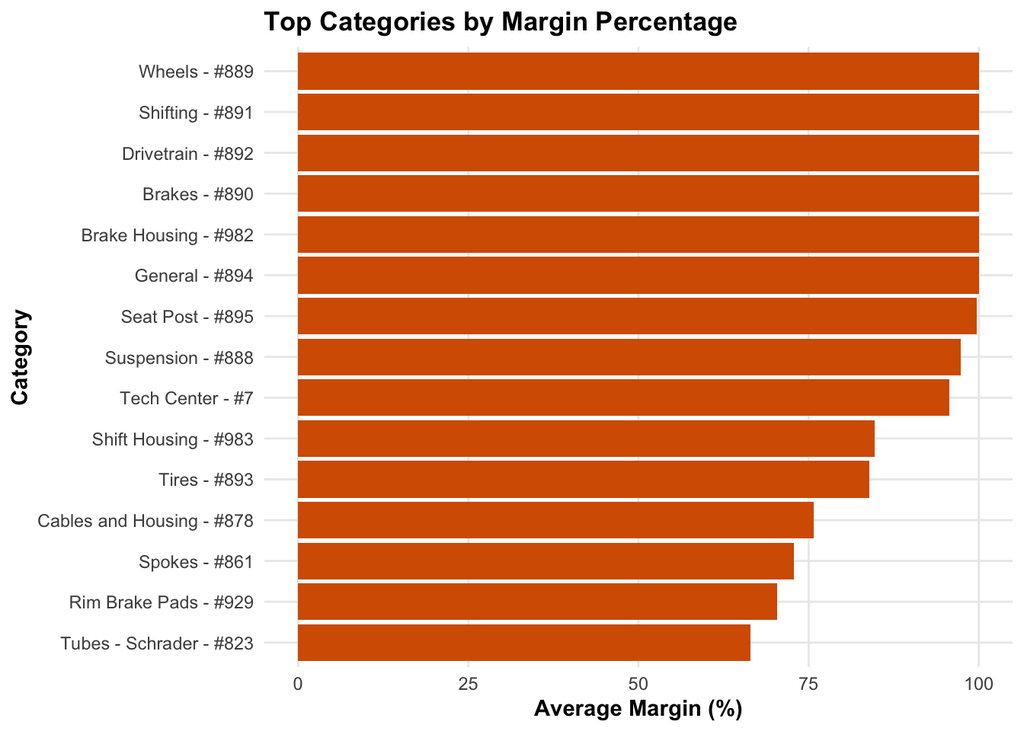

```r
margin_plot_data <- margin_plot_data %>% slice_max(MarginPct, n = 15)
ggplot(margin_plot_data,
aes(x = reorder(Category, MarginPct), y = MarginPct)) +
geom_col(fill = accent) +
coord_flip() +
labs(
title = "Top Categories by Margin Percentage",
x = "Category",
y = "Average Margin (%)"
) +
theme_ev
```

### Plot 2: Monthly Sales Trend

**Interpretation:** Revenue follows a strong seasonal pattern, climbing rapidly in spring and peaking in summer before dropping through the winter months. This reflects typical riding, competition, and repair cycles in a mountain bike retail environment.

```r
monthly_sales <- daily_sales %>%
  mutate(
    Month = as.Date(floor_date(Date, unit = "month"))
  ) %>%
  group_by(Month) %>%
  summarise(
    Total_Revenue = sum(Total, na.rm = TRUE),
    Total_Profit  = sum(Profit, na.rm = TRUE)
  )
```

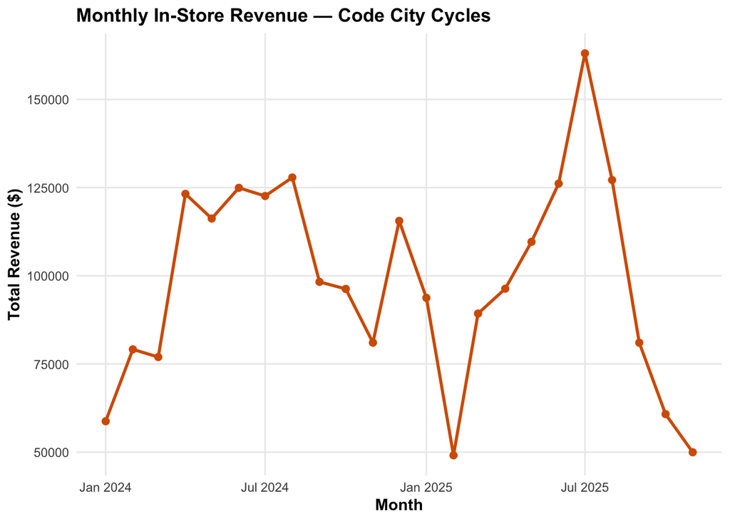

```r
ggplot(monthly_sales, aes(x = Month, y = Total_Revenue)) +
  geom_line(color = accent, linewidth = 1) +
  geom_point(color = accent, size = 2) +
  labs(
    title = "Monthly In-Store Revenue — Code City Cycles",
    x = "Month",
    y = "Total Revenue ($)"
  ) +
  scale_x_date(date_labels = "%b %Y") +
  theme_ev
```

### Plot 3: Revenue Share by Category (Top 10)

**Interpretation:** Full suspension bikes generate the largest share of revenue, with other bike categories and key parts groups like Brakes, General items, and Suspension also making meaningful contributions to overall sales.

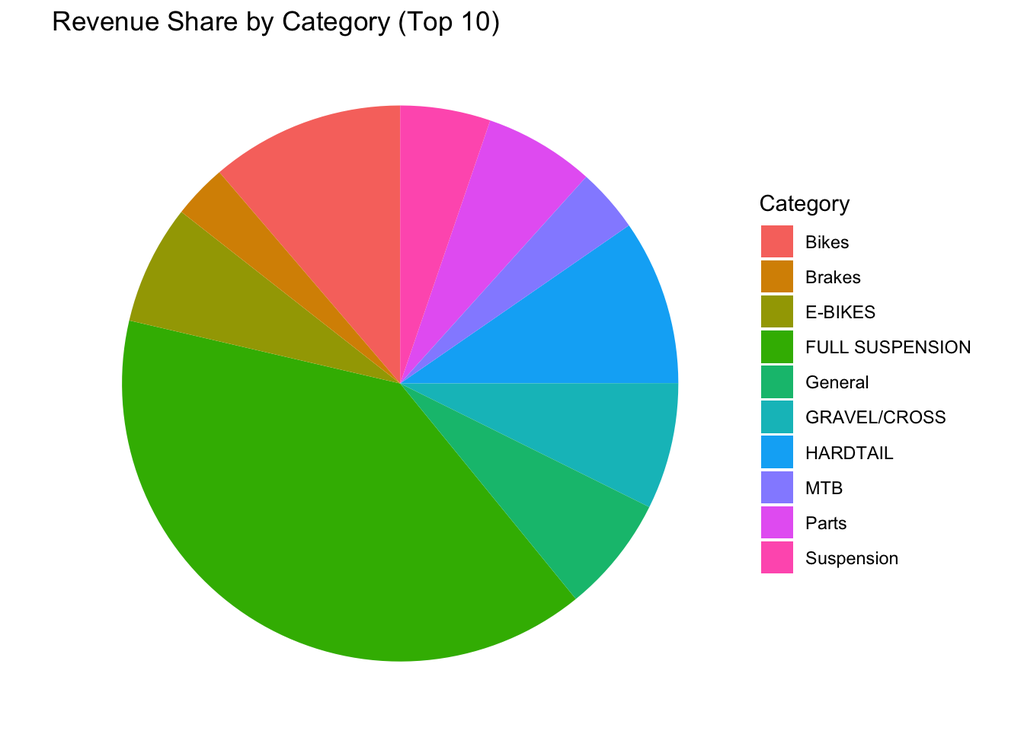

```r
revenue_share <- category_revenue_agg %>%
mutate(Share = Total_Revenue / sum(Total_Revenue) * 100) %>%
arrange(desc(Share)) %>%
slice_max(Share, n = 10)

ggplot(revenue_share,
aes(x = "", y = Share, fill = Category)) +
geom_bar(stat = "identity", width = 1) +
coord_polar("y") +
labs(
title = "Revenue Share by Category (Top 10)",
y = "Share (%)",
x = ""
) +
theme_void() +
theme(legend.position = "right")
```

## Pattern Recognition

### Category Profitability

High-margin small parts - such as Wheels, Shifting components, Brakes, and General shop supplies - consistently outperform complete bikes in profitability. These categories offer strong percentage margins and steady turnover, indicating they play a key role in sustaining overall shop profitability despite representing lower individual ticket values.

### Seasonal Revenue

Sales show a clear seasonal cycle, with revenue peaking from late spring through midsummer and declining sharply in winter months. This pattern reflects predictable riding behavior and suggests that inventory levels, staffing, and purchasing should ramp up ahead of peak season and contract during slower winter periods.

# 4. Strategic Recommendations